# Predicting House Prices

Niklas Pettersson-Fox

2026-05-21

# Introduction

This project participates in the **Kaggle House Prices - Advanced Regression Techniques** competition. The goal is to predict the final sale price of residential homes in Ames, Iowa, using a comprehensive dataset containing 79 explanatory variables describing every aspect of the houses (from square footage and quality to features like fireplaces, garages, and pool quality).

## Project Objectives

- Achieve a strong predictive performance on unseen test data (measured by Root Mean Squared Logarithmic Error - RMSLE)
- Build a well-specified and interpretable linear regression model
- Thoroughly validate model assumptions and document the modeling decisions
- Submit competitive predictions to the Kaggle leaderboard

Its crucial to get an idea of the data set and a summary statistic is often useful to gain information on our data. We first read in the data and mutate our characted variables to factors for analysis purposes when we need them. For now we will not as the following analysis is going to only consider the numerical variables.

```r
train <- read.csv("train.csv")

library(dplyr)
train <- train %>%
  mutate(across(where(is.character), as.factor))

train$MSSubClass <- as.factor(train$MSSubClass)
summary(train)
```

```
##        Id           MSSubClass     MSZoning     LotFrontage
##  Min.   :   1.0   20     :536   C (all):  10   Min.   : 21.00
##  1st Qu.: 365.8   60     :299   FV     :  65   1st Qu.: 59.00
##  Median : 730.5   50     :144   RH     :  16   Median : 69.00
##  Mean   : 730.5   120    : 87   RL     :1151   Mean   : 70.05
##  3rd Qu.:1095.2   30     : 69   RM     : 218   3rd Qu.: 80.00
##  Max.   :1460.0   160    : 63                  Max.   :313.00
##                   (Other):262                  NAs    :259
##     LotArea        Street      Alley      LotShape  LandContour  Utilities
##  Min.   :  1300   Grvl:   6   Grvl:  50   IR1:484   Bnk:  63    AllPub:1459
##  1st Qu.:  7554   Pave:1454   Pave:  41   IR2: 41   HLS:  50    NoSeWa:   1
##  Median :  9478               NAs :1369   IR3: 10   Low:  36
##  Mean   : 10517                           Reg:925   Lvl:1311
##  3rd Qu.: 11602
##  Max.   :215245
##
##    LotConfig    LandSlope   Neighborhood   Condition1     Condition2
##  Corner : 263   Gtl:1382   NAmes  :225   Norm   :1260   Norm   :1445
##  CulDSac:  94   Mod:  65   CollgCr:150   Feedr  :  81   Feedr  :   6
##  FR2    :  47   Sev:  13   OldTown:113   Artery :  48   Artery :   2
##  FR3    :   4              Edwards:100   RRAn   :  26   PosN   :   2
##  Inside :1052              Somerst: 86   PosN   :  19   RRNn   :   2
##                            Gilbert: 79   RRAe   :  11   PosA   :   1
##                            (Other):707   (Other):  15   (Other):   2
##    BldgType      HouseStyle   OverallQual      OverallCond      YearBuilt
##  1Fam  :1220   1Story :726   Min.   : 1.000   Min.   :1.000   Min.   :1872
##  2fmCon:  31   2Story :445   1st Qu.: 5.000   1st Qu.:5.000   1st Qu.:1954
##  Duplex:  52   1.5Fin :154   Median : 6.000   Median :5.000   Median :1973
##  Twnhs :  43   SLvl   : 65   Mean   : 6.099   Mean   :5.575   Mean   :1971
##  TwnhsE: 114   SFoyer : 37   3rd Qu.: 7.000   3rd Qu.:6.000   3rd Qu.:2000
##                1.5Unf : 14   Max.   :10.000   Max.   :9.000   Max.   :2010
##                (Other): 19
##   YearRemodAdd    RoofStyle       RoofMatl     Exterior1st   Exterior2nd
##  Min.   :1950   Flat   :  13   CompShg:1434   VinylSd:515   VinylSd:504
##  1st Qu.:1967   Gable  :1141   Tar&Grv:  11   HdBoard:222   MetalSd:214
##  Median :1994   Gambrel:  11   WdShngl:   6   MetalSd:220   HdBoard:207
##  Mean   :1985   Hip    : 286   WdShake:   5   Wd Sdng:206   Wd Sdng:197
##  3rd Qu.:2004   Mansard:   7   ClyTile:   1   Plywood:108   Plywood:142
##  Max.   :2010   Shed   :   2   Membran:   1   CemntBd: 61   CmentBd: 60
##                                (Other):   2   (Other):128   (Other):136
```

[output cut: 81 more lines]

```
##  Min.   :    0.00   Min.   : 1.000   Min.   :2006   WD     :1267
##  1st Qu.:    0.00   1st Qu.: 5.000   1st Qu.:2007   New    : 122
##  Median :    0.00   Median : 6.000   Median :2008   COD    :  43
##  Mean   :   43.49   Mean   : 6.322   Mean   :2008   ConLD  :   9
##  3rd Qu.:    0.00   3rd Qu.: 8.000   3rd Qu.:2009   ConLI  :   5
##  Max.   :15500.00   Max.   :12.000   Max.   :2010   ConLw  :   5
##                                                     (Other):   9
##  SaleCondition    SalePrice
##  Abnorml: 101   Min.   : 34900
##  AdjLand:   4   1st Qu.:129975
##  Alloca :  12   Median :163000
##  Family :  20   Mean   :180921
##  Normal :1198   3rd Qu.:214000
##  Partial: 125   Max.   :755000
##
```

Now that our data only includes numerical variables (for model simplicity purposes and curiosity of the power of this subset), we can set up our first model.

```r
model <- lm(SalePrice ~ ., data = num_vars_df)
summary(model)
```

```
##
## Call:
## lm(formula = SalePrice ~ ., data = num_vars_df)
##
## Residuals:
##     Min      1Q  Median      3Q     Max
## -497980  -16701   -1933   13823  308740
##
## Coefficients: (2 not defined because of singularities)
##                 Estimate Std. Error t value Pr(>|t|)
## (Intercept)    1.560e+05  1.431e+06   0.109 0.913252
## Id            -1.291e+00  2.217e+00  -0.583 0.560288
## LotFrontage    5.264e+01  2.860e+01   1.840 0.065920 .
## LotArea        4.499e-01  1.019e-01   4.416 1.08e-05 ***
## OverallQual    1.647e+04  1.200e+03  13.725  < 2e-16 ***
## OverallCond    4.806e+03  1.037e+03   4.633 3.94e-06 ***
## YearBuilt      3.151e+02  6.174e+01   5.104 3.77e-07 ***
## YearRemodAdd   1.607e+02  6.700e+01   2.399 0.016587 *
## MasVnrArea     2.909e+01  6.020e+00   4.832 1.50e-06 ***
## BsmtFinSF1     2.010e+01  4.733e+00   4.248 2.30e-05 ***
## BsmtFinSF2     8.953e+00  7.155e+00   1.251 0.211016
## BsmtUnfSF      1.084e+01  4.253e+00   2.547 0.010957 *
## TotalBsmtSF           NA         NA      NA       NA
## X1stFlrSF      4.931e+01  5.850e+00   8.429  < 2e-16 ***
## X2ndFlrSF      4.147e+01  4.920e+00   8.428  < 2e-16 ***
## LowQualFinSF   1.789e+01  1.995e+01   0.897 0.369936
## GrLivArea             NA         NA      NA       NA
## BsmtFullBath   7.942e+03  2.638e+03   3.011 0.002652 **
## BsmtHalfBath   3.683e+02  4.140e+03   0.089 0.929118
## FullBath       3.151e+03  2.852e+03   1.105 0.269363
## HalfBath      -1.386e+03  2.702e+03  -0.513 0.608147
## BedroomAbvGr  -9.036e+03  1.704e+03  -5.304 1.31e-07 ***
## KitchenAbvGr  -2.447e+04  4.936e+03  -4.957 8.01e-07 ***
## TotRmsAbvGrd   5.860e+03  1.250e+03   4.688 3.02e-06 ***
## Fireplaces     3.637e+03  1.796e+03   2.025 0.043074 *
## GarageCars     1.048e+04  2.895e+03   3.621 0.000304 ***
## GarageArea     2.595e+00  9.832e+00   0.264 0.791851
## WoodDeckSF     2.601e+01  8.109e+00   3.207 0.001369 **
## OpenPorchSF    1.029e+00  1.537e+01   0.067 0.946635
## EnclosedPorch  1.328e+01  1.710e+01   0.777 0.437504
## X3SsnPorch     2.286e+01  3.184e+01   0.718 0.472869
## ScreenPorch    5.470e+01  1.743e+01   3.139 0.001731 **
## PoolArea      -4.008e+01  2.407e+01  -1.666 0.096014 .
## MiscVal       -1.977e-01  1.885e+00  -0.105 0.916476
## MoSold         2.957e+01  3.496e+02   0.085 0.932610
## YrSold        -5.777e+02  7.115e+02  -0.812 0.417022
## ---
## Signif. codes:  0 '***' 0.001 '**' 0.01 '*' 0.05 '.' 0.1 ' ' 1
##
## Residual standard error: 35250 on 1426 degrees of freedom
## Multiple R-squared:  0.8076, Adjusted R-squared:  0.8031
## F-statistic: 181.3 on 33 and 1426 DF,  p-value: < 2.2e-16
```

There are a lot of statistically insignificant variables which we will remove one by one or in sets if the p-value is very large, as they will never be significant, so anything aboove 0.5 will be removed right away and also log SalePrice as this is common practice given the exponential nature of house prices.

```r
model1 <- lm(SalePrice ~ ., data = num_vars_df[,-c(1,12,16)] )
#summary(model1)
model2 <- lm(SalePrice ~ ., data = num_vars_df[,-c(1,12,16,33,34,35,28,18)] )
#summary(model2)
model3 <- lm(SalePrice ~ ., data = num_vars_df[,-c(1,12,16,33,34,35,28,18,26,20)] )
#summary(model3)
model4 <- lm(SalePrice ~ ., data = num_vars_df[,-c(1,12,16,33,34,35,28,18,26,20,30,29,15)] )
#summary(model4)
model5 <- lm(log(SalePrice) ~ ., data = num_vars_df[,-c(1,12,16,33,34,35,28,18,26,20,30,29,15)] )
#summary(model5)
model6 <- lm(log(SalePrice) ~ ., data = num_vars_df[,-c(1,12,16,33,34,35,28,18,26,20,30,29,15,2,8,21)] )
summary(model6)
```

```
##
## Call:
## lm(formula = log(SalePrice) ~ ., data = num_vars_df[, -c(1, 12,
##     16, 33, 34, 35, 28, 18, 26, 20, 30, 29, 15, 2, 8, 21)])
##
## Residuals:
##      Min       1Q   Median       3Q      Max
## -2.01055 -0.06767  0.00578  0.07979  0.51970
##
## Coefficients:
##                Estimate Std. Error t value Pr(>|t|)
## (Intercept)   3.048e+00  5.259e-01   5.796 8.35e-09 ***
## LotArea       2.035e-06  4.274e-07   4.761 2.12e-06 ***
## OverallQual   8.218e-02  4.910e-03  16.737  < 2e-16 ***
## OverallCond   4.913e-02  4.275e-03  11.492  < 2e-16 ***
## YearBuilt     2.746e-03  2.262e-04  12.139  < 2e-16 ***
## YearRemodAdd  1.069e-03  2.750e-04   3.887 0.000106 ***
## BsmtFinSF1    8.774e-05  1.947e-05   4.507 7.09e-06 ***
## BsmtFinSF2    7.940e-05  2.984e-05   2.661 0.007889 **
## BsmtUnfSF     6.262e-05  1.772e-05   3.534 0.000422 ***
## X1stFlrSF     2.054e-04  2.415e-05   8.506  < 2e-16 ***
## X2ndFlrSF     1.660e-04  1.754e-05   9.465  < 2e-16 ***
## BsmtFullBath  5.429e-02  1.054e-02   5.149 2.98e-07 ***
## FullBath      2.731e-02  1.093e-02   2.498 0.012617 *
## KitchenAbvGr -1.028e-01  2.052e-02  -5.008 6.18e-07 ***
## TotRmsAbvGrd  2.028e-02  4.543e-03   4.463 8.70e-06 ***
## Fireplaces    4.503e-02  7.425e-03   6.065 1.69e-09 ***
## GarageCars    7.724e-02  7.179e-03  10.758  < 2e-16 ***
## WoodDeckSF    1.107e-04  3.374e-05   3.280 0.001061 **
## ScreenPorch   3.371e-04  7.246e-05   4.653 3.58e-06 ***
## PoolArea     -3.674e-04  9.977e-05  -3.682 0.000240 ***
## ---
## Signif. codes:  0 '***' 0.001 '**' 0.01 '*' 0.05 '.' 0.1 ' ' 1
##
## Residual standard error: 0.1487 on 1440 degrees of freedom
## Multiple R-squared:  0.8632, Adjusted R-squared:  0.8614
## F-statistic: 478.2 on 19 and 1440 DF,  p-value: < 2.2e-16
```

We must verify that the model satisfies the key assumptions of linear regression:

- **Linearity**: The relationship between the predictors and the response variable is linear.
- **Independence of errors**: The residuals are independent of each other.
- **Homoscedasticity**: The variance of the residuals is constant across all levels of the fitted values.
- **Normality of residuals**: The residuals are approximately normally distributed.
- **No severe multicollinearity**: The predictors are not highly correlated with each other.

In the following section, we perform a series of diagnostic checks to assess whether these assumptions hold.

[figure not shown]

```r
library(tidyverse)
library(performance)   # for nice checks
library(car)           # for VIF and other diagnostics
library(ggfortify)     # optional: ggplot2 versions of base plots
library(patchwork)     # for combining plots nicely
```

In the Posterior Predictive Checks section of the above plot, we can see that the model fits well for most regions of SalesPrice, except for around the median value of Sales price. This pairs well with the Linearity plot, as it is clear that the reference line is not linear and the points also deviate from the line, hence we should check for some non-linear relationships between our predictors and Sales price.

There is also evidence to suggest that there is non-equal variance (non-homogeneity of variance) as the reference line is clearly not flat, showing a quadratic shape, although the spread above and below the line is quite uniform, which is good.

Some evidence of multicollinearity in our model, 5 of the variables with a variance inflation factor (VIF) >= 5, hence we should consider which variables these are and remove the colinear variables.

And finally, a look at the Normality of the residuals shows us that they are fairly normal expect for the tails where there is some clear deviation. Once we address the non-linear relationships, remove the influential observation and the collinear variables, this plot should follow the line more closely.

## Addressing Model Assumption Findings

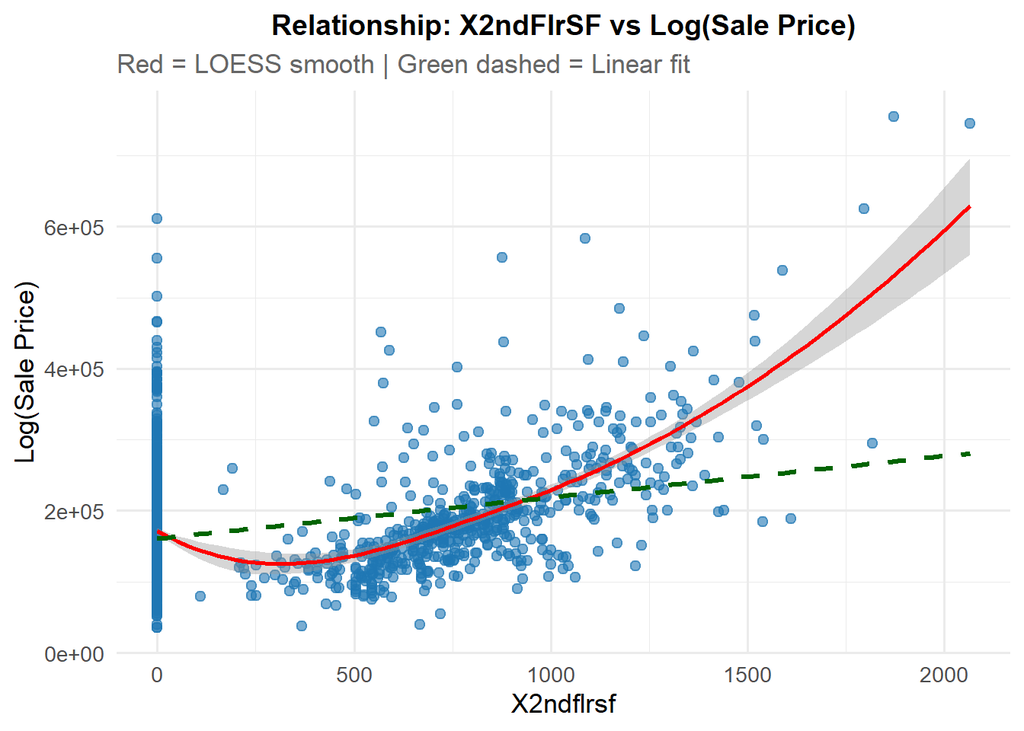

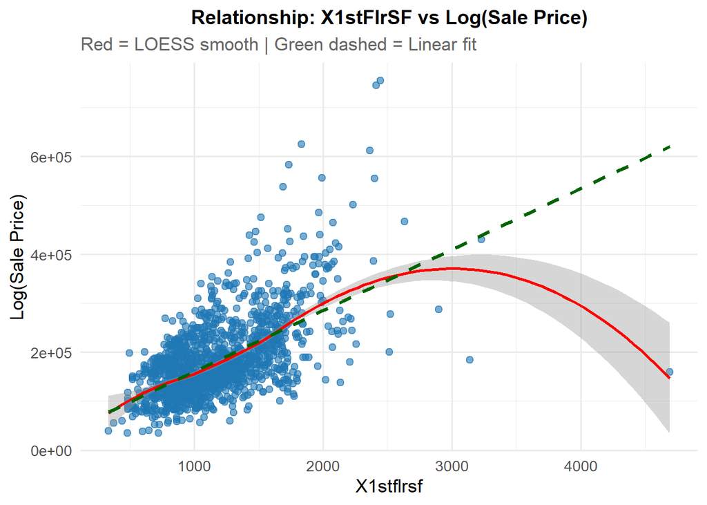

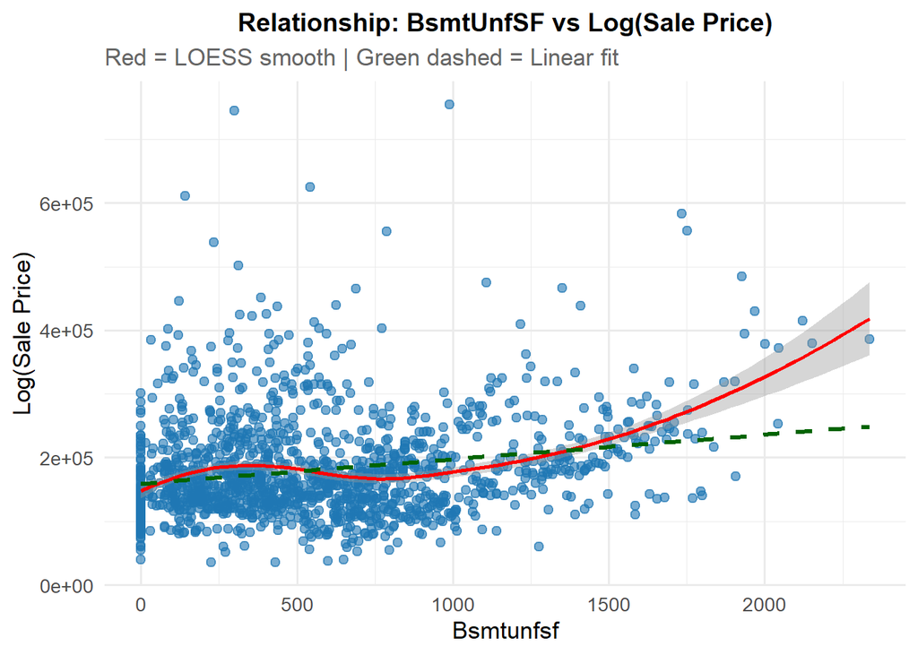

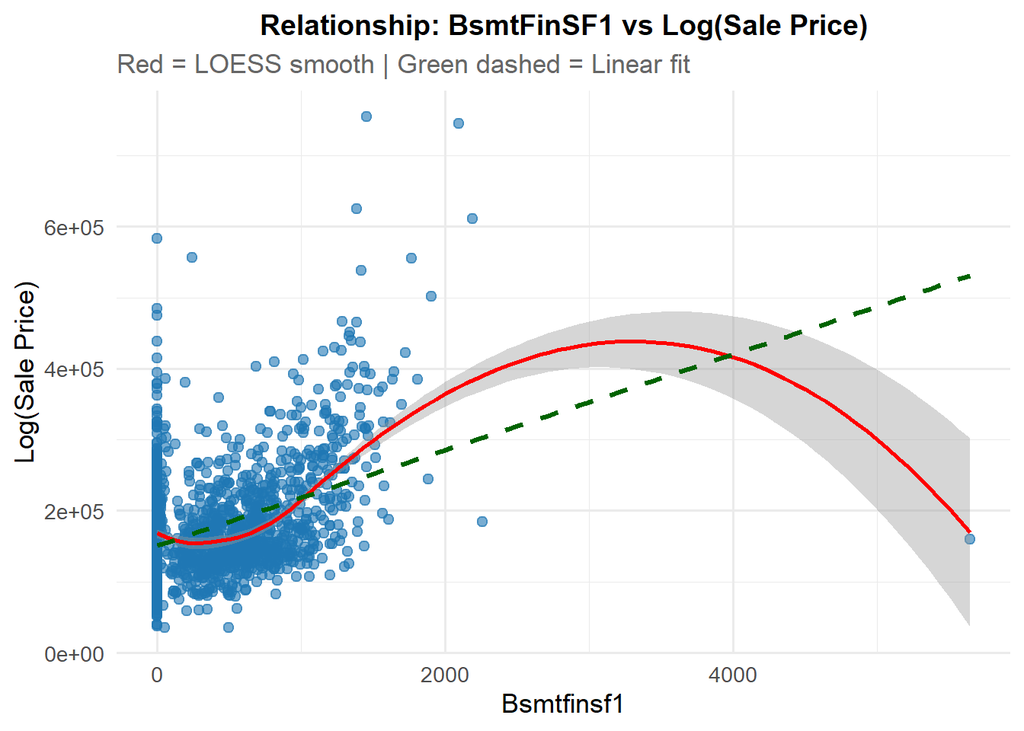

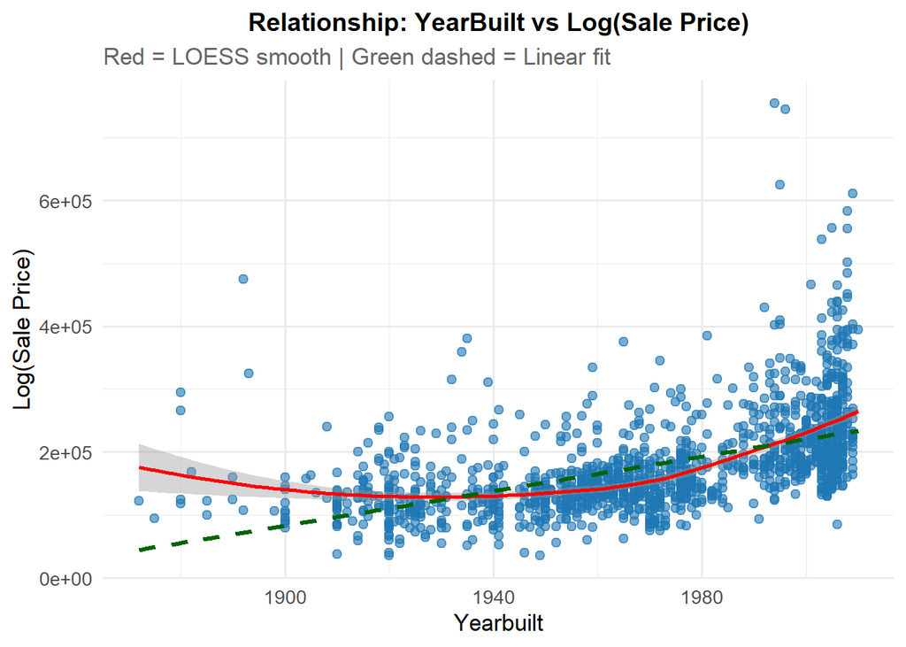

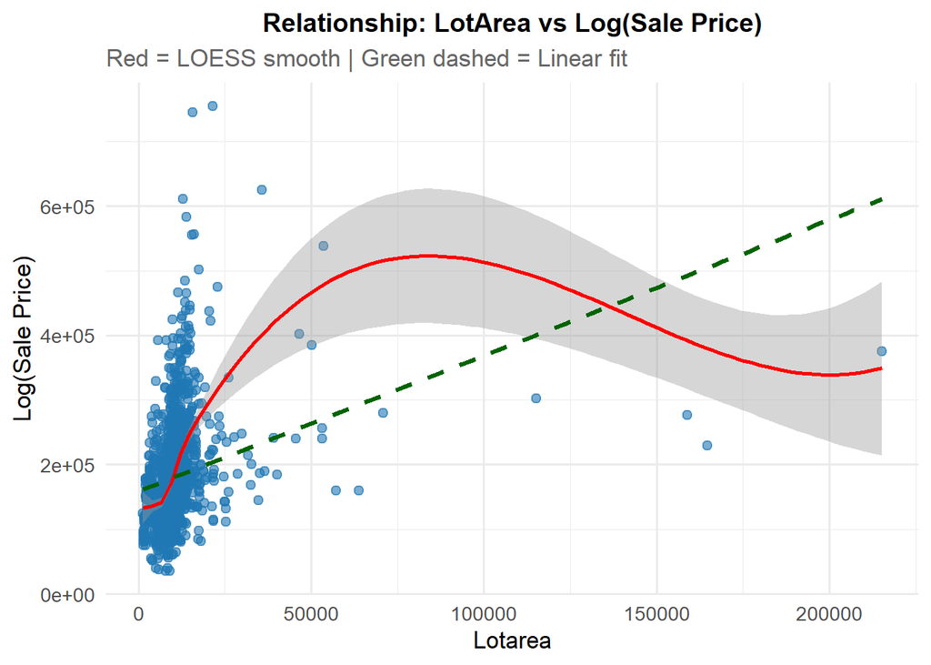

As we can see, there are some clearly non-linear relationships that need to be taken care of to improve our model and meet the required assumptions of a linear model. But a few of the plots show a non-linear relationship due to one observation dragging the line away, hence we should take care to remove this observation and check for linearity again.

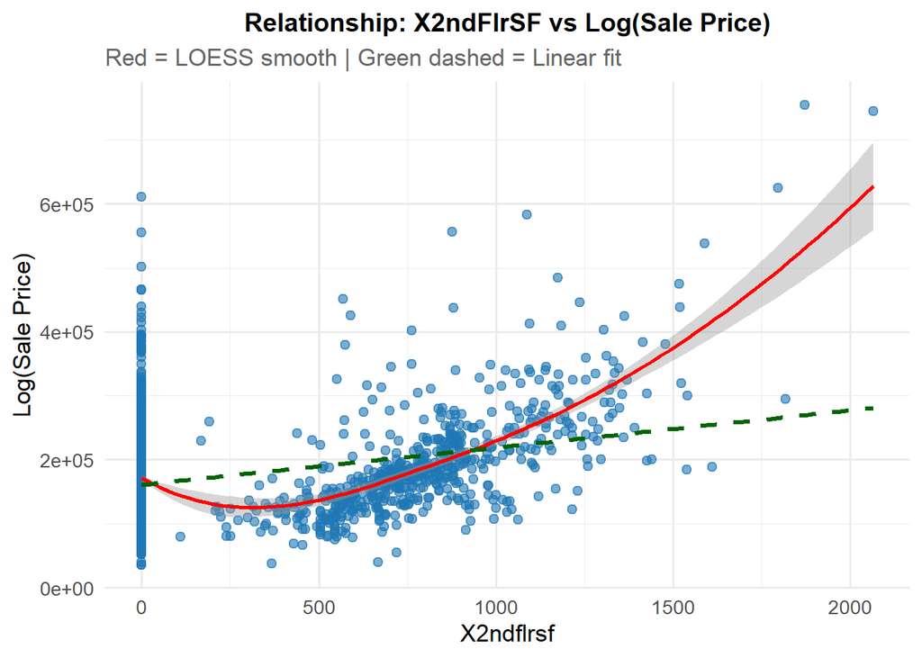

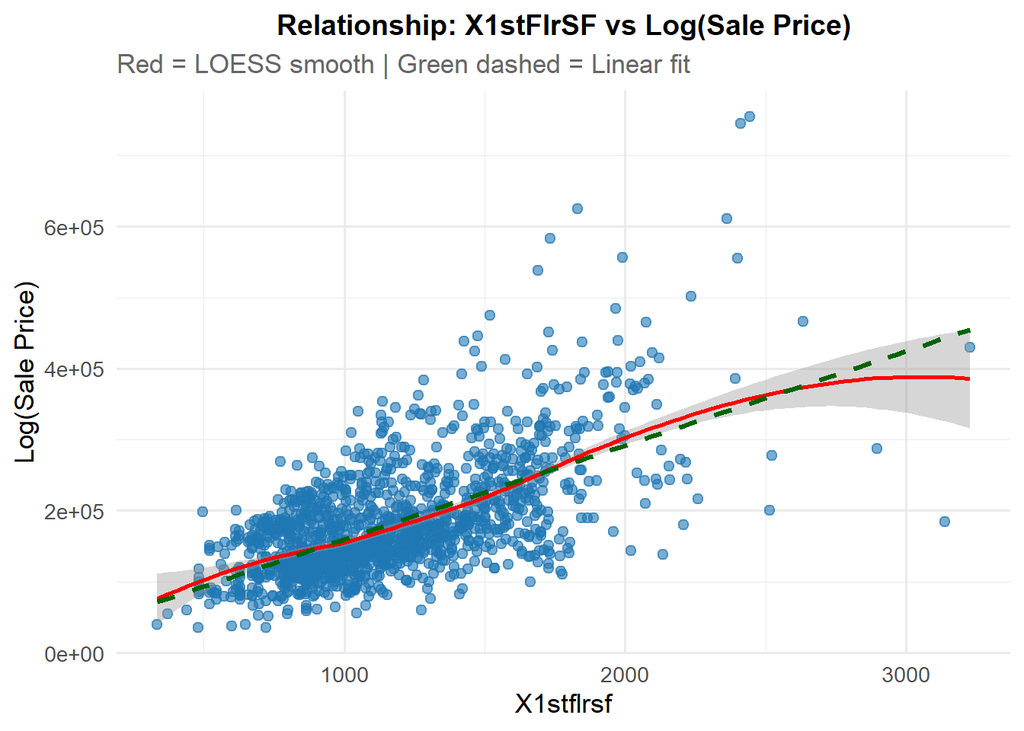

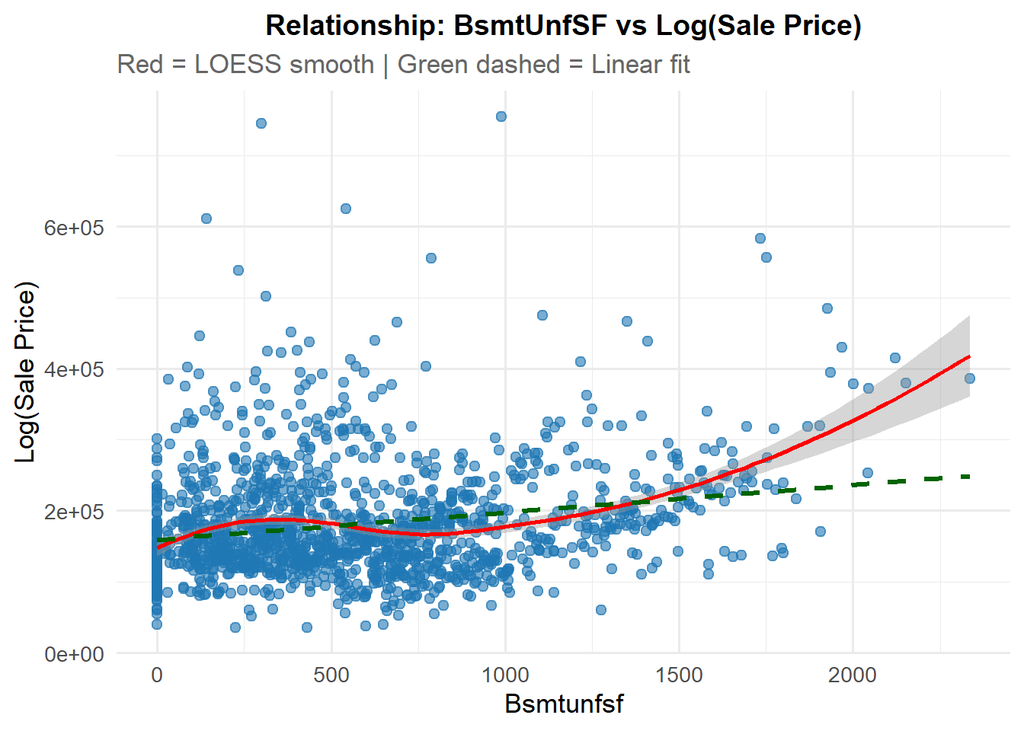

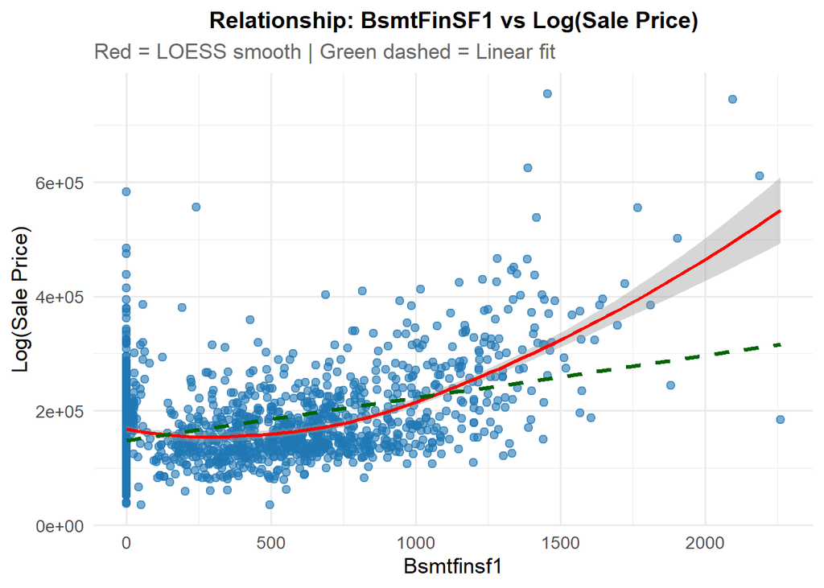

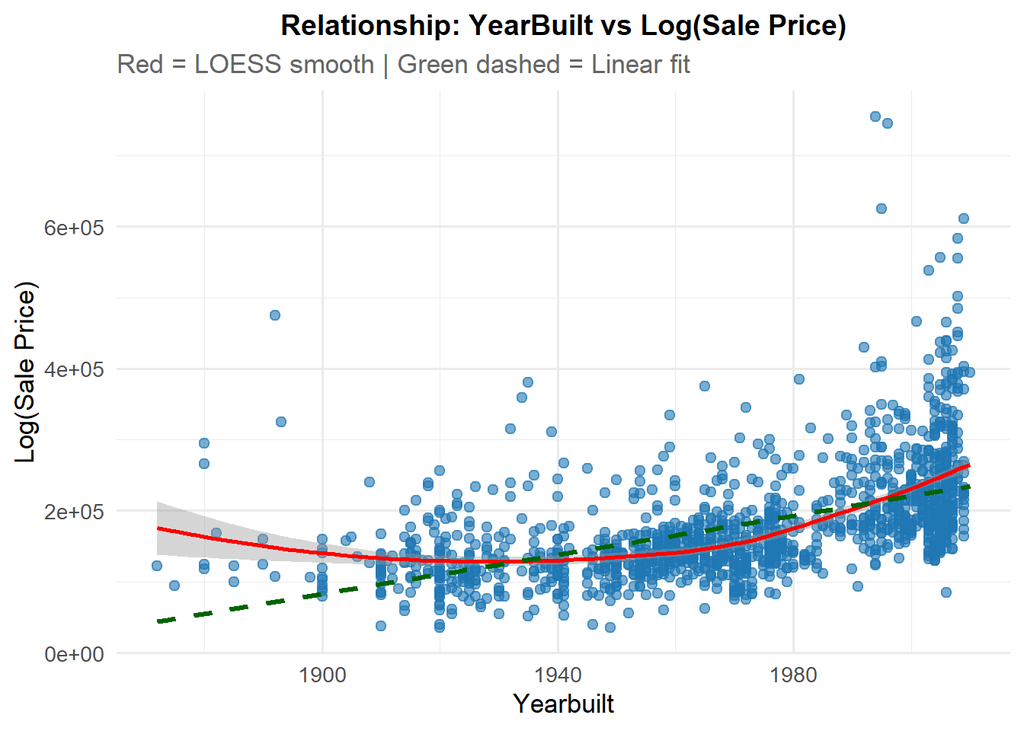

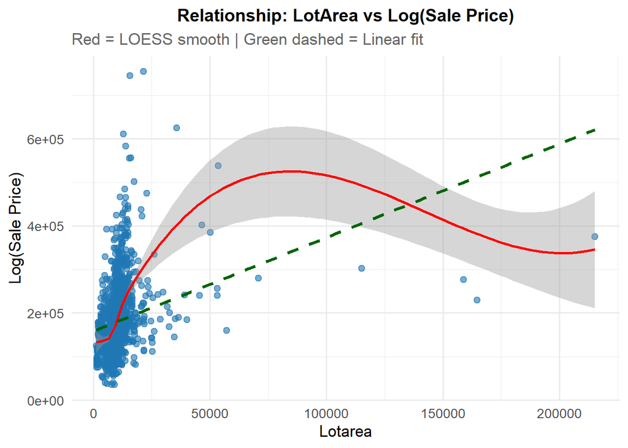

Removing the influential observation, was a wise choice, it was changing the relationship drastically. Regardless, these variables still have a nonlinear relationship which should be taken care of.

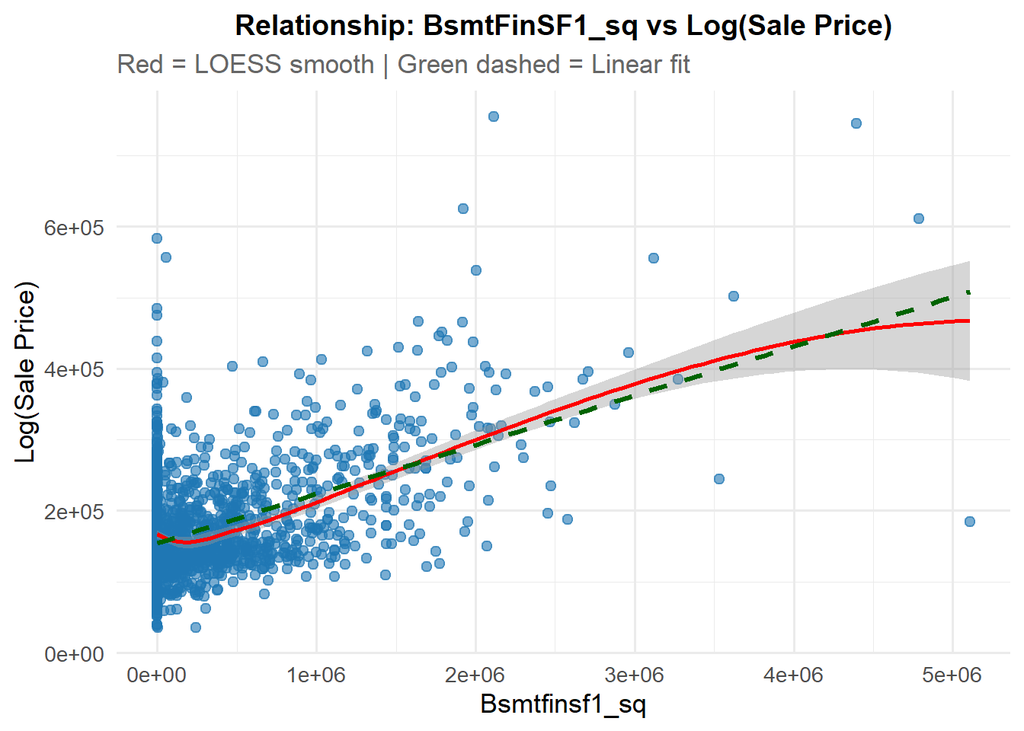

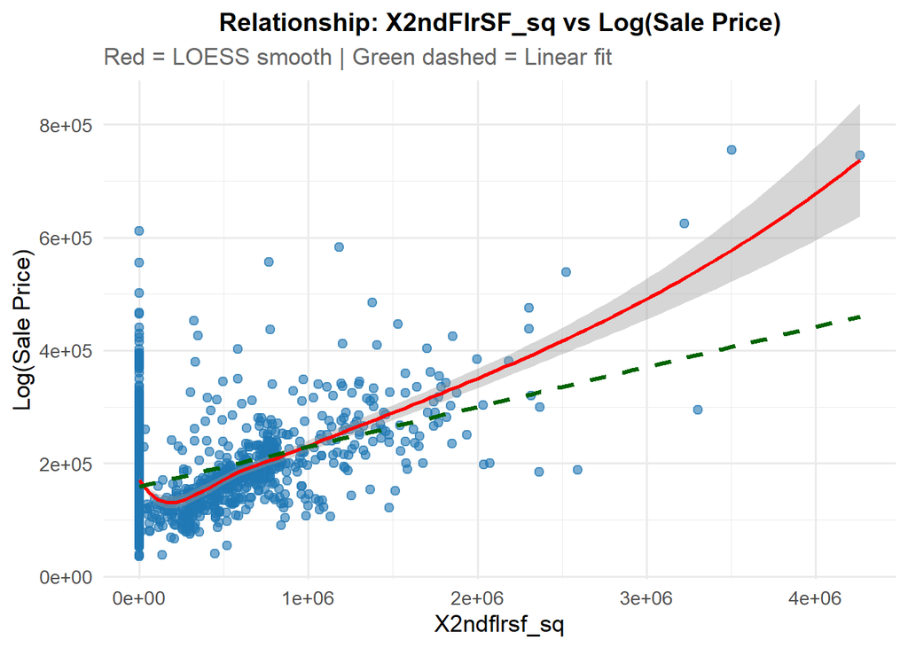

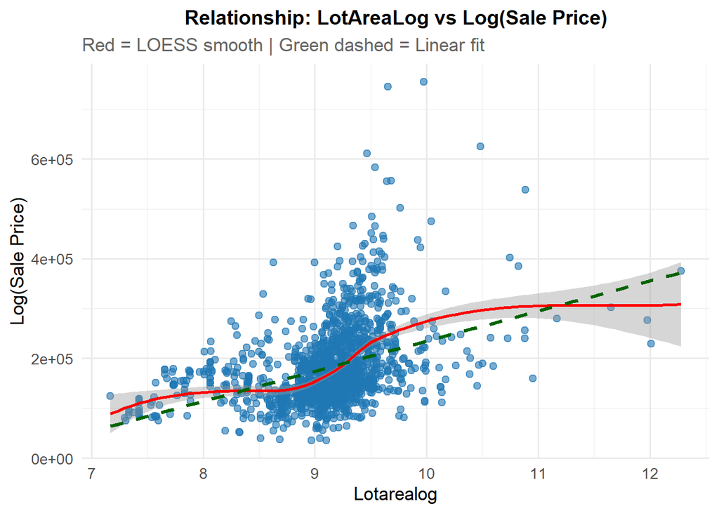

This is definitely an improvement, however it appears some observations are still making the relationships askew, but we will check if they are influecing the model afterwards. Now we will consider multicollinearity.

```r
#more details
collinearity <- check_collinearity(model)
print(collinearity)
```

```
## # Check for Multicollinearity
##
## Low Correlation
##
##           Term  VIF   VIF 95% CI adj. VIF Tolerance Tolerance 95% CI
##             Id 1.15 [1.10, 1.24]     1.07      0.87     [0.81, 0.91]
##    LotFrontage 1.21 [1.15, 1.30]     1.10      0.82     [0.77, 0.87]
##        LotArea 3.24 [2.98, 3.53]     1.80      0.31     [0.28, 0.34]
##    OverallQual 1.56 [1.47, 1.68]     1.25      0.64     [0.59, 0.68]
##    OverallCond 4.08 [3.74, 4.46]     2.02      0.24     [0.22, 0.27]
##      YearBuilt 2.25 [2.08, 2.43]     1.50      0.45     [0.41, 0.48]
##   YearRemodAdd 1.39 [1.31, 1.49]     1.18      0.72     [0.67, 0.76]
##     BsmtFinSF1 1.56 [1.47, 1.68]     1.25      0.64     [0.59, 0.68]
##     BsmtFinSF2 4.15 [3.80, 4.53]     2.04      0.24     [0.22, 0.26]
##      X1stFlrSF 1.10 [1.06, 1.19]     1.05      0.91     [0.84, 0.94]
##      X2ndFlrSF 2.20 [2.04, 2.38]     1.48      0.45     [0.42, 0.49]
##   LowQualFinSF 1.15 [1.09, 1.23]     1.07      0.87     [0.81, 0.91]
##      GrLivArea 2.90 [2.67, 3.15]     1.70      0.34     [0.32, 0.37]
##   BsmtFullBath 2.17 [2.01, 2.35]     1.47      0.46     [0.43, 0.50]
##   BsmtHalfBath 2.27 [2.10, 2.46]     1.51      0.44     [0.41, 0.48]
##       FullBath 1.39 [1.31, 1.49]     1.18      0.72     [0.67, 0.76]
##       HalfBath 4.85 [4.44, 5.31]     2.20      0.21     [0.19, 0.23]
##   BedroomAbvGr 1.57 [1.48, 1.69]     1.25      0.64     [0.59, 0.68]
##     Fireplaces 1.21 [1.15, 1.30]     1.10      0.82     [0.77, 0.87]
##     GarageCars 1.22 [1.16, 1.30]     1.10      0.82     [0.77, 0.86]
##     GarageArea 1.28 [1.21, 1.37]     1.13      0.78     [0.73, 0.82]
##     WoodDeckSF 1.02 [1.00, 1.22]     1.01      0.98     [0.82, 1.00]
##    OpenPorchSF 1.11 [1.06, 1.19]     1.05      0.90     [0.84, 0.94]
##  EnclosedPorch 1.10 [1.05, 1.18]     1.05      0.91     [0.85, 0.95]
##     X3SsnPorch 1.03 [1.00, 1.19]     1.01      0.97     [0.84, 1.00]
##    ScreenPorch 1.05 [1.02, 1.15]     1.02      0.95     [0.87, 0.98]
##       PoolArea 1.05 [1.02, 1.15]     1.02      0.95     [0.87, 0.98]
##
## Moderate Correlation
##
##          Term  VIF   VIF 95% CI adj. VIF Tolerance Tolerance 95% CI
##    MasVnrArea 5.47 [5.00, 6.00]     2.34      0.18     [0.17, 0.20]
##     BsmtUnfSF 6.01 [5.49, 6.59]     2.45      0.17     [0.15, 0.18]
##   TotalBsmtSF 5.42 [4.95, 5.94]     2.33      0.18     [0.17, 0.20]
##  KitchenAbvGr 5.50 [5.02, 6.02]     2.34      0.18     [0.17, 0.20]
##  TotRmsAbvGrd 5.19 [4.75, 5.68]     2.28      0.19     [0.18, 0.21]
```

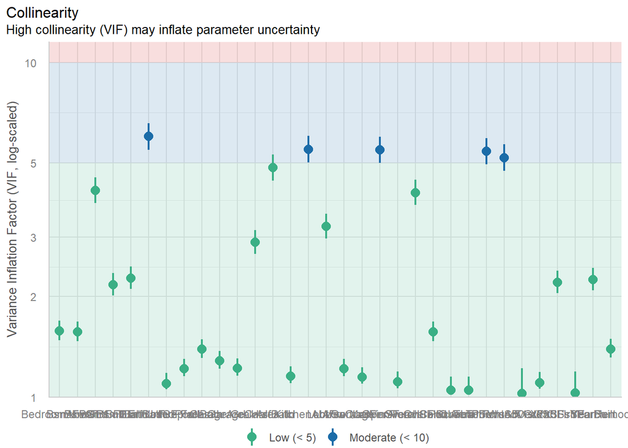

```r
# Nice plot
plot(collinearity)
```

We should now remove one of the terms which have a moderate correlation but is also the least likely to be important to the model. BsmtUnfSF is the total square foot area of unfinished basement, it has the highest correlation and it may be useful but I will make the decision to remove it as this would perhaps only be important for very expensive houses who have unfinished work in the house.

```r
modelnew <- lm(log(SalePrice) ~ ., data = num_vars_df[,-c(1,11,12,16,33,34,35,28,18,26,20,30,29,15,2,8,21)] )
summary(modelnew)
```

```
##
## Call:
## lm(formula = log(SalePrice) ~ ., data = num_vars_df[, -c(1, 11,
##     12, 16, 33, 34, 35, 28, 18, 26, 20, 30, 29, 15, 2, 8, 21)])
##
## Residuals:
##      Min       1Q   Median       3Q      Max
## -1.54005 -0.06190  0.00491  0.07221  0.44678
##
## Coefficients:
##                 Estimate Std. Error t value Pr(>|t|)
## (Intercept)    1.449e+00  5.002e-01   2.898 0.003816 **
## LotArea       -2.811e-07  5.094e-07  -0.552 0.581187
## OverallQual    8.751e-02  4.372e-03  20.015  < 2e-16 ***
## OverallCond    4.534e-02  3.893e-03  11.645  < 2e-16 ***
## YearBuilt      2.889e-03  2.086e-04  13.848  < 2e-16 ***
## YearRemodAdd   1.345e-03  2.496e-04   5.389 8.28e-08 ***
## BsmtFinSF1     1.019e-04  3.866e-05   2.635 0.008502 **
## BsmtFinSF2     2.193e-05  2.510e-05   0.874 0.382329
## X1stFlrSF      2.964e-04  2.015e-05  14.707  < 2e-16 ***
## X2ndFlrSF      3.428e-04  8.941e-05   3.834 0.000132 ***
## BsmtFullBath   2.898e-02  9.658e-03   3.001 0.002741 **
## FullBath       1.239e-02  9.928e-03   1.248 0.212237
## KitchenAbvGr  -9.166e-02  1.866e-02  -4.912 1.00e-06 ***
## TotRmsAbvGrd   7.957e-03  4.190e-03   1.899 0.057766 .
## Fireplaces     3.428e-02  6.708e-03   5.111 3.63e-07 ***
## GarageCars     5.788e-02  6.567e-03   8.814  < 2e-16 ***
## WoodDeckSF     6.603e-05  3.055e-05   2.161 0.030824 *
## ScreenPorch    2.474e-04  6.542e-05   3.782 0.000162 ***
## PoolArea       4.516e-05  9.466e-05   0.477 0.633382
## LotAreaLog     9.281e-02  1.086e-02   8.544  < 2e-16 ***
## Has2ndFlr     -5.536e-02  3.890e-02  -1.423 0.154944
## X2ndFlrSF_sq  -7.038e-08  4.689e-08  -1.501 0.133605
## HasBsmnt       8.406e-03  1.518e-02   0.554 0.579698
## BsmtFinSF1_sq -2.232e-08  2.330e-08  -0.958 0.338299
## ---
## Signif. codes:  0 '***' 0.001 '**' 0.01 '*' 0.05 '.' 0.1 ' ' 1
##
## Residual standard error: 0.1339 on 1435 degrees of freedom
## Multiple R-squared:  0.8896, Adjusted R-squared:  0.8878
## F-statistic: 502.5 on 23 and 1435 DF,  p-value: < 2.2e-16
```

```
## Ignoring unknown labels:
## • size : ""
```

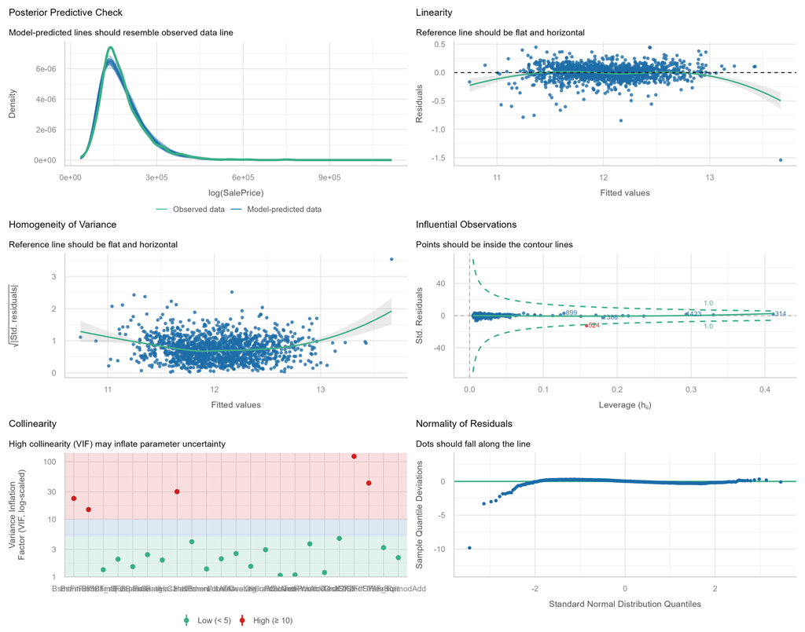

Great improvement in the linear model assumptions, we can see that the model prediction is very close to the observed data across all ranges now but we have introduced some strong multicollinearity but this is due to the non-linear predictors we added to the model, but to confirm this, lets check it. We should also remove observation 524, as it clearly is outside of the range of expected values.

```r
collinearity <- check_collinearity(modelnew)
print(collinearity)
```

```
## # Check for Multicollinearity
##
## Low Correlation
##
##          Term  VIF       VIF 95% CI adj. VIF Tolerance Tolerance 95% CI
##       LotArea 2.06 [  1.92,   2.23]     1.44      0.48     [0.45, 0.52]
##   OverallQual 2.96 [  2.73,   3.23]     1.72      0.34     [0.31, 0.37]
##   OverallCond 1.53 [  1.43,   1.64]     1.24      0.65     [0.61, 0.70]
##     YearBuilt 3.23 [  2.97,   3.52]     1.80      0.31     [0.28, 0.34]
##  YearRemodAdd 2.16 [  2.01,   2.34]     1.47      0.46     [0.43, 0.50]
##    BsmtFinSF2 1.33 [  1.26,   1.43]     1.16      0.75     [0.70, 0.79]
##     X1stFlrSF 4.66 [  4.26,   5.10]     2.16      0.21     [0.20, 0.23]
##  BsmtFullBath 2.03 [  1.89,   2.20]     1.43      0.49     [0.45, 0.53]
##      FullBath 2.44 [  2.25,   2.64]     1.56      0.41     [0.38, 0.44]
##  KitchenAbvGr 1.38 [  1.30,   1.48]     1.17      0.73     [0.68, 0.77]
##  TotRmsAbvGrd 3.75 [  3.44,   4.10]     1.94      0.27     [0.24, 0.29]
##    Fireplaces 1.51 [  1.42,   1.62]     1.23      0.66     [0.62, 0.71]
##    GarageCars 1.96 [  1.82,   2.12]     1.40      0.51     [0.47, 0.55]
##    WoodDeckSF 1.19 [  1.13,   1.28]     1.09      0.84     [0.78, 0.88]
##   ScreenPorch 1.08 [  1.04,   1.17]     1.04      0.92     [0.86, 0.96]
##      PoolArea 1.06 [  1.03,   1.16]     1.03      0.94     [0.87, 0.97]
##    LotAreaLog 2.55 [  2.35,   2.77]     1.60      0.39     [0.36, 0.42]
##      HasBsmnt 4.08 [  3.74,   4.46]     2.02      0.25     [0.22, 0.27]
##
## High Correlation
##
##           Term    VIF       VIF 95% CI adj. VIF Tolerance Tolerance 95% CI
##     BsmtFinSF1  23.07 [ 20.90,  25.46]     4.80      0.04     [0.04, 0.05]
##      X2ndFlrSF 123.89 [112.06, 136.97]    11.13  8.07e-03     [0.01, 0.01]
##      Has2ndFlr  30.24 [ 27.39,  33.40]     5.50      0.03     [0.03, 0.04]
##   X2ndFlrSF_sq  42.56 [ 38.53,  47.02]     6.52      0.02     [0.02, 0.03]
##  BsmtFinSF1_sq  14.77 [ 13.41,  16.29]     3.84      0.07     [0.06, 0.07]
```

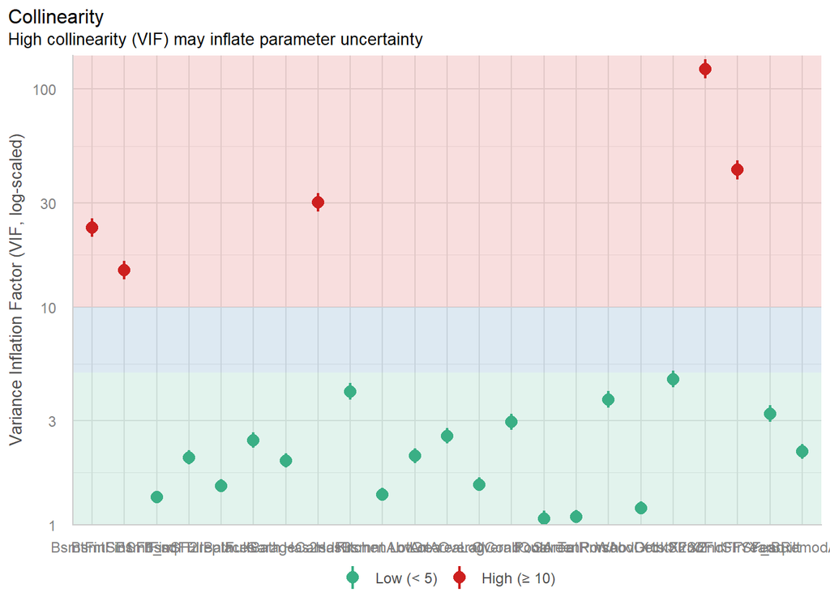

```r
# Nice plot
plot(collinearity)
```

As expected, the high correlation variables are the non-linear terms and the logical variables, we will not remove them for that reason.

```r
#Removing the influential observation
#num_vars_df <- num_vars_df[-524,]

modelnew <- lm(log(SalePrice) ~ ., data = num_vars_df[,-c(1,11,12,16,33,34,35,28,18,26,20,30,29,15,2,8,21)] )
summary(modelnew)
```

```
##
## Call:
## lm(formula = log(SalePrice) ~ ., data = num_vars_df[, -c(1, 11,
##     12, 16, 33, 34, 35, 28, 18, 26, 20, 30, 29, 15, 2, 8, 21)])
##
## Residuals:
##      Min       1Q   Median       3Q      Max
## -1.54005 -0.06190  0.00491  0.07221  0.44678
##
## Coefficients:
##                 Estimate Std. Error t value Pr(>|t|)
## (Intercept)    1.449e+00  5.002e-01   2.898 0.003816 **
## LotArea       -2.811e-07  5.094e-07  -0.552 0.581187
## OverallQual    8.751e-02  4.372e-03  20.015  < 2e-16 ***
## OverallCond    4.534e-02  3.893e-03  11.645  < 2e-16 ***
## YearBuilt      2.889e-03  2.086e-04  13.848  < 2e-16 ***
## YearRemodAdd   1.345e-03  2.496e-04   5.389 8.28e-08 ***
## BsmtFinSF1     1.019e-04  3.866e-05   2.635 0.008502 **
## BsmtFinSF2     2.193e-05  2.510e-05   0.874 0.382329
## X1stFlrSF      2.964e-04  2.015e-05  14.707  < 2e-16 ***
## X2ndFlrSF      3.428e-04  8.941e-05   3.834 0.000132 ***
## BsmtFullBath   2.898e-02  9.658e-03   3.001 0.002741 **
## FullBath       1.239e-02  9.928e-03   1.248 0.212237
## KitchenAbvGr  -9.166e-02  1.866e-02  -4.912 1.00e-06 ***
## TotRmsAbvGrd   7.957e-03  4.190e-03   1.899 0.057766 .
## Fireplaces     3.428e-02  6.708e-03   5.111 3.63e-07 ***
## GarageCars     5.788e-02  6.567e-03   8.814  < 2e-16 ***
## WoodDeckSF     6.603e-05  3.055e-05   2.161 0.030824 *
## ScreenPorch    2.474e-04  6.542e-05   3.782 0.000162 ***
## PoolArea       4.516e-05  9.466e-05   0.477 0.633382
## LotAreaLog     9.281e-02  1.086e-02   8.544  < 2e-16 ***
## Has2ndFlr     -5.536e-02  3.890e-02  -1.423 0.154944
## X2ndFlrSF_sq  -7.038e-08  4.689e-08  -1.501 0.133605
## HasBsmnt       8.406e-03  1.518e-02   0.554 0.579698
## BsmtFinSF1_sq -2.232e-08  2.330e-08  -0.958 0.338299
## ---
## Signif. codes:  0 '***' 0.001 '**' 0.01 '*' 0.05 '.' 0.1 ' ' 1
##
## Residual standard error: 0.1339 on 1435 degrees of freedom
## Multiple R-squared:  0.8896, Adjusted R-squared:  0.8878
## F-statistic: 502.5 on 23 and 1435 DF,  p-value: < 2.2e-16
```

```r
modelnew2 <- lm(log(SalePrice) ~ ., data = num_vars_df[,-c(1,10,11,12,16,33,34,35,28,18,26,20,30,29,15,2,8,21)] )
summary(modelnew2)
```

```
##
## Call:
## lm(formula = log(SalePrice) ~ ., data = num_vars_df[, -c(1, 10,
##     11, 12, 16, 33, 34, 35, 28, 18, 26, 20, 30, 29, 15, 2, 8,
##     21)])
##
## Residuals:
##      Min       1Q   Median       3Q      Max
## -1.54368 -0.06194  0.00443  0.07198  0.44729
##
## Coefficients:
##                 Estimate Std. Error t value Pr(>|t|)
## (Intercept)    1.468e+00  4.996e-01   2.939 0.003345 **
## LotArea       -2.521e-07  5.083e-07  -0.496 0.619932
## OverallQual    8.734e-02  4.367e-03  19.998  < 2e-16 ***
## OverallCond    4.549e-02  3.890e-03  11.695  < 2e-16 ***
## YearBuilt      2.890e-03  2.086e-04  13.856  < 2e-16 ***
## YearRemodAdd   1.333e-03  2.493e-04   5.349 1.03e-07 ***
## BsmtFinSF1     9.170e-05  3.686e-05   2.488 0.012974 *
## X1stFlrSF      2.985e-04  2.000e-05  14.929  < 2e-16 ***
## X2ndFlrSF      3.479e-04  8.921e-05   3.899 0.000101 ***
## BsmtFullBath   3.106e-02  9.358e-03   3.320 0.000924 ***
## FullBath       1.229e-02  9.927e-03   1.238 0.215854
## KitchenAbvGr  -9.218e-02  1.865e-02  -4.943 8.61e-07 ***
## TotRmsAbvGrd   7.801e-03  4.186e-03   1.864 0.062578 .
## Fireplaces     3.431e-02  6.707e-03   5.116 3.54e-07 ***
## GarageCars     5.780e-02  6.566e-03   8.802  < 2e-16 ***
## WoodDeckSF     6.803e-05  3.046e-05   2.233 0.025682 *
## ScreenPorch    2.521e-04  6.520e-05   3.867 0.000115 ***
## PoolArea       4.844e-05  9.458e-05   0.512 0.608615
## LotAreaLog     9.292e-02  1.086e-02   8.556  < 2e-16 ***
## Has2ndFlr     -5.757e-02  3.882e-02  -1.483 0.138272
## X2ndFlrSF_sq  -7.278e-08  4.681e-08  -1.555 0.120221
## HasBsmnt       1.300e-02  1.424e-02   0.913 0.361333
## BsmtFinSF1_sq -1.914e-08  2.301e-08  -0.832 0.405746
## ---
## Signif. codes:  0 '***' 0.001 '**' 0.01 '*' 0.05 '.' 0.1 ' ' 1
##
## Residual standard error: 0.1338 on 1436 degrees of freedom
## Multiple R-squared:  0.8895, Adjusted R-squared:  0.8878
## F-statistic: 525.4 on 22 and 1436 DF,  p-value: < 2.2e-16
```

Lets check our assumptions:

```
## Ignoring unknown labels:
## • size : ""
```

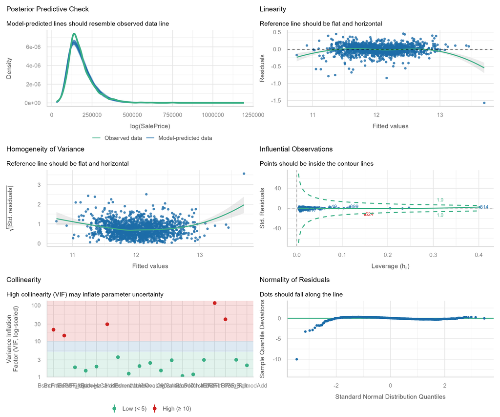

### Model Diagnostics Summary

We are now ready to generate predictions on the test dataset and submit our results to Kaggle.